# Simple Linear Regression

### Problem Statement:-

- Build a model to predict weight gained using calories consumed

### Data Understanding

```r
cal <- read.csv("~/desktop/Digi 360/Module 6/DataSets-4/calories_consumed.csv")
head(cal)
```

```
##   Weight.gained..grams. Calories.Consumed
## 1                   108              1500
## 2                   200              2300
## 3                   900              3400
## 4                   200              2200
## 5                   300              2500
## 6                   110              1600
```

```r
#renaming the columns
colnames(cal) <- c("weight_gained", "cals_consumed")
```

```r
# checking the summary
summary(cal)
```

```
##  weight_gained    cals_consumed
##  Min.   :  62.0   Min.   :1400
##  1st Qu.: 114.5   1st Qu.:1728
##  Median : 200.0   Median :2250
##  Mean   : 357.7   Mean   :2341
##  3rd Qu.: 537.5   3rd Qu.:2775
##  Max.   :1100.0   Max.   :3900
```

Here, the mean is greater than the median for weight gained so the distribution is right skewed.

Similarly, the mean is greater than the median for calories consumed so the distribution is right skewed.

### Visualization

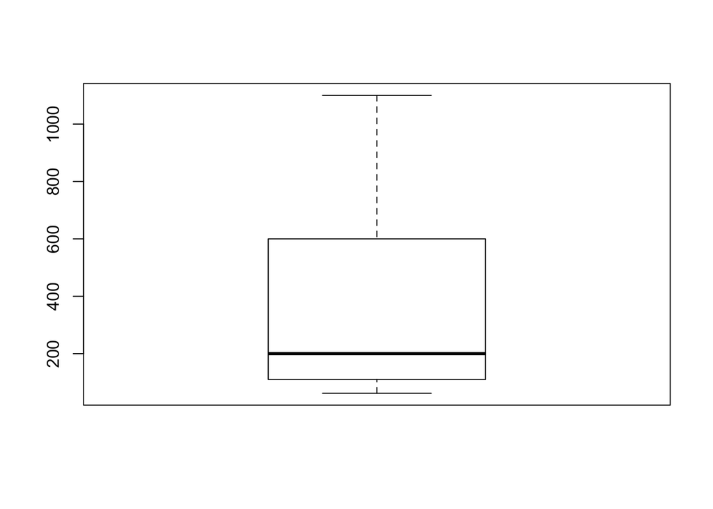

```r
boxplot(cal$weight_gained)
```

So, there are no outliers.

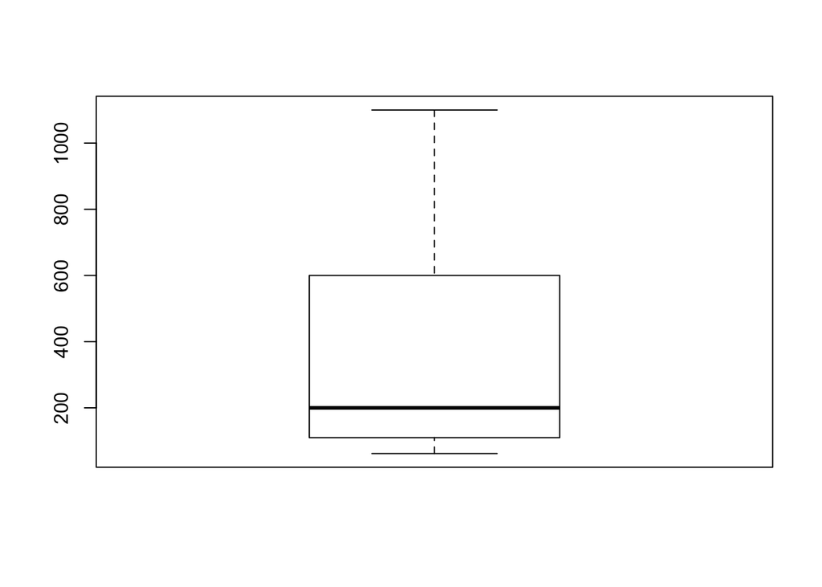

```r
y <- boxplot(cal$weight_gained)
```

```r
y$out
```

```
## numeric(0)
```

So, there are no outliers.

Let’s draw scatter diagram to see the relationship between weight gained and calories consumed.

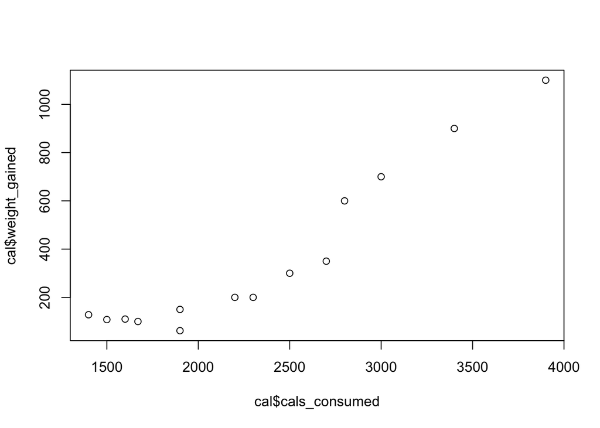

```r
plot(cal$cals_consumed, cal$weight_gained) # Scatter plot
```

### Correlation

```r
cor(cal$cals_consumed, cal$weight_gained)
```

```
## [1] 0.946991
```

Here the correlation coefficient value is 0.95 which is greater than 0.85. So, the relationship between weight gained and calories consumed is strong

### Building the model

```r
model <- lm(cal$weight_gained ~ cal$cals_consumed)
summary(model)
```

```
##
## Call:
## lm(formula = cal$weight_gained ~ cal$cals_consumed)
##
## Residuals:
##     Min      1Q  Median      3Q     Max
## -158.67 -107.56   36.70   81.68  165.53
##
## Coefficients:
##                     Estimate Std. Error t value Pr(>|t|)
## (Intercept)       -625.75236  100.82293  -6.206 4.54e-05 ***
## cal$cals_consumed    0.42016    0.04115  10.211 2.86e-07 ***
## ---
## Signif. codes:  0 '***' 0.001 '**' 0.01 '*' 0.05 '.' 0.1 ' ' 1
##
## Residual standard error: 111.6 on 12 degrees of freedom
## Multiple R-squared:  0.8968, Adjusted R-squared:  0.8882
## F-statistic: 104.3 on 1 and 12 DF,  p-value: 2.856e-07
```

### Model Evolution

Here p value is less than 0.05 so we reject the null hypothesis. That means there is significant correlation between weight gained and calories consumed.

Here we also can see R-squared value is 0.8968 which is greater than 0.85. Hence our model is good and we don’t need further transformations.

Since we are ready with equation, let’s predict the values with 95% CI level.

```r
pred <- predict(model, cal)
model$residuals
```

```
##          1          2          3          4          5          6          7
##  103.51740 -140.60791   97.21979  -98.59224 -124.63924   63.50174  165.53306
##          8          9         10         11         12         13         14
## -110.54525   49.31377   87.14147   24.09077  -22.54525 -158.67056   65.28245
```

```r
confint(model, level =0.95)
```

```
##                          2.5 %       97.5 %
## (Intercept)       -845.4266546 -406.0780569
## cal$cals_consumed    0.3305064    0.5098069
```

```r
predict(model, interval = "confidence")
```

```
##            fit        lwr        upr
## 1     4.482599  -95.02772  103.99291
## 2   340.607908  275.53138  405.68443
## 3   802.780209  687.71491  917.84550
## 4   298.592245  232.40485  364.77964
## 5   424.639236  358.11443  491.16404
## 6    46.498263  -46.40643  139.40296
## 7   -37.533065 -143.99464   68.92851
## 8   172.545254   96.50131  248.58920
## 9   550.686227  473.76407  627.60838
## 10 1012.858527  858.70611 1167.01094
## 11   75.909227  -12.61880  164.43725
## 12  172.545254   96.50131  248.58920
## 13  508.670563  436.15078  581.19034
## 14  634.717554  546.88222  722.55289
```

### Accuracy

Now let’s find out the accuracy.

```r
#Finding RMSE
rmse <- sqrt(mean(model$residuals^2))
rmse
```

```
## [1] 103.3025
```

So, we can conclude that our predicted values are 103 points deviated from actual values.

Now let’s visualize the predicted values using a ggplot to add a regression line to it.

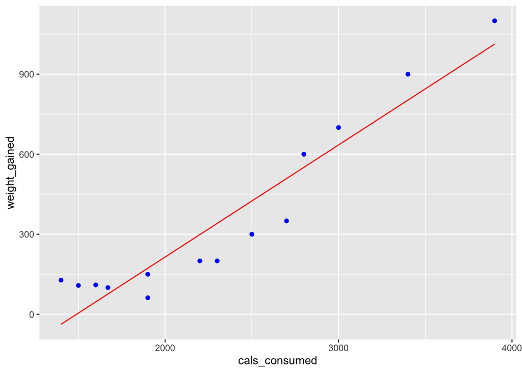

```r
library(ggplot2)
ggplot(data=cal,aes (x = cals_consumed, y = weight_gained)) +
 geom_point(color='blue') +
 geom_line(color = 'red', data=cal,aes (x = cals_consumed, y = pred))
```

### Conclusion:-

- The model R^2 is 0.90. So, our model is good.